# Spatial Bayes Introduction

Raven McKnight

4/14/2019

Birth control is a critical aspect of basic health care. Accessible contraceptive services have numerous tangible benefits from reducing teen pregnancy to lowering abortion rates. At the most basic level, birth control empowers women to navigate the world and their health more freely. The “pro-life” movement and current political climate put this vital resource at risk. With this in mind, I decided to study access to birth control in the United States.

This project was initially inspired by a map by [Power to Decide](https://powertodecide.org/what-we-do/access/access-birth-control). Based on the work of Richard Cooper, MD, this organization defines a *contraceptive desert* as a region where there are fewer than one birth control provider per 1000 women in need. This map (and my project) focus on publicly funded services and the women who need them.

Admittedly, access is more nuanced than the simple presence of clinics. There are many other factors to consider: physical accessibility (proximity to transit lines, etc), stigma, under-education regarding contraception, or any other number of personal characteristics. I’m considering this simple ratio of women per clinic as a first step in studying birth control accessibility.

For this project, I use county-level data about women in need of services and service providers collected by the Guttmacher Institute from 2014-2015. My demographic data is drawn from 2015 ACS 5-year estimates and my county boundaries from the Urban Institute.

### The Data

First, let’s load the packages we’ll need.

```r
library(urbnmapr)
library(wesanderson)
library(rjags)
library(MCMCvis)
library(tidyverse)
```

Now, we can load the data: `bc` is a data frame of cleaned ACS and Guttmacher data. `bc_spatial` is the same data joined to county boundaries from the Urban Institute!

```r
bc <- read_csv("/Users/raven/Documents/Classes/BayesCapstone/ravenData_Apr17.csv")

counties <- urbnmapr::counties %>%
  mutate(fips = as.numeric(county_fips))  # create field to join on

bc_spatial <- full_join(bc, counties, by ="fips")   # join with county data from urbnmapr
```

For this analysis, we’ll focus on the following predictors.

| **variable** | **meaning** |
| --- | --- |
| TotalClinics | Number of publicly funded clinics providing birth control services by county, Guttmacher |
| TotalWomen | Total women age 13-44 who can become pregnant but don’t want to *and* who need publicly funded contraceptives, Guttmacher |
| TotalWomenUnder20 | Total women under 20 who need publicly funded services, Guttmacher |
| TotalPop | Total county population, ACS 2015 |
| MedianInc | Median county income, ACS 2015 |
| PercHSGrad | Percent of county with high school diploma or equivalent, ACS 2015 |
| PercPoverty | Percent of county living below poverty line, ACS 2015 |
| PercWhite, PercBlack …. | Seven variables recording racial demographics of each county, ACS 2015 |
| PercRural | Percent of population living in rural area, ACS 2015 |
| Region | Categorical variable recording US region for each state |
| ObamaPercent | Percent of the 2012 vote Obama got by *state* |
| WomenPerClinic | Simple ratio of TotalWomen/TotalClinics |
| Desert | Simple yes/no categorical variable, is the county a desert? |

\

### Visualization and Exploration

A natural first visualization is to check where contraceptive deserts in the United States are. We can map the simple yes/no `desert` variable to get a sense of where there’s less than one clinic per 1000 women in need.

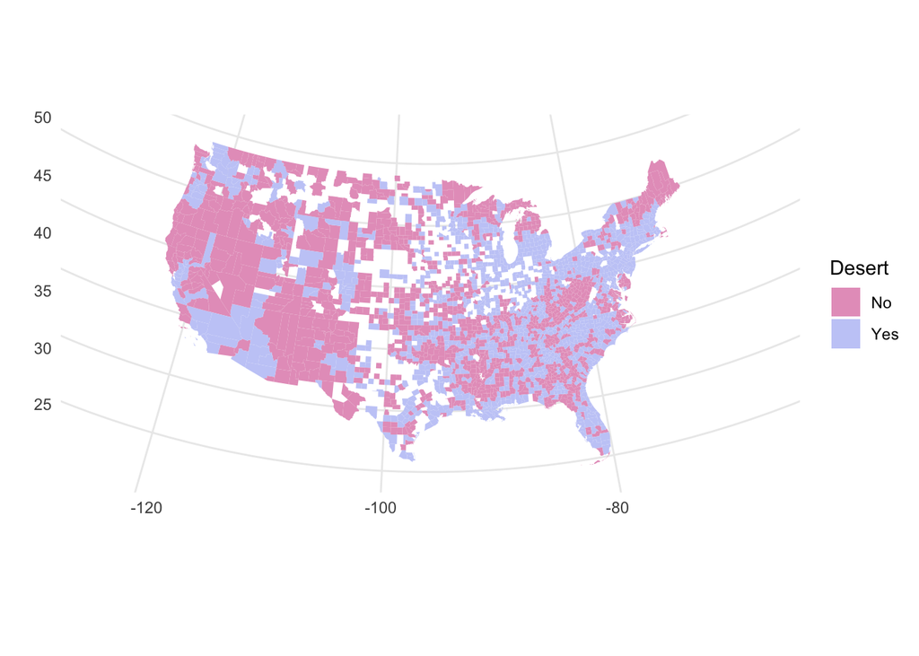

```r
bc_spatial_na <- bc_spatial %>%
  filter(!is.na(desert))   # remove NAs for mapping

ggplot() +
  geom_polygon(data = bc_spatial_na, mapping = aes(x = long, y = lat, group = group, fill = bc_spatial_na$desert), color = "NA") +
  coord_map(projection = "albers", lat0 = 39, lat1 = 45) +
  scale_fill_manual(values=wes_palette(n=3, name="GrandBudapest2")) +
  labs(x="", y="") +
  guides(fill=guide_legend(title="Desert")) +
  theme_minimal()
```

We are missing a lot of data about rural counties in the middle of the country. Many of these counties simply don’t report how many birth control clinics they have. By summarizing, we can see that these counties tend to be more rural and less highly populated than those counties which do report clinic data.

```r
counties_missing_data <- bc %>%
  filter(is.na(WomenPerClinic)) %>%
  select(TotalWomen, TotalWomenUnder20, TotalPop, MedianInc, PercHSGrad, PercRural, PercPoverty, PercWhite, obamaPercent)  # selection for summary purposes

sapply(counties_missing_data, mean, na.rm=TRUE)
```

```
##        TotalWomen TotalWomenUnder20          TotalPop         MedianInc
##            989.98            301.23          30534.03          49848.04
##        PercHSGrad         PercRural       PercPoverty         PercWhite
##             87.44              0.71              0.13             88.28
##      obamaPercent
##              0.45
```

```r
no_missing_data <- bc %>%
  filter(!is.na(WomenPerClinic)) %>%
  select(TotalWomen, TotalWomenUnder20, TotalPop, MedianInc, PercHSGrad, PercRural, PercPoverty, PercWhite, obamaPercent)  # selection for summary purposes

sapply(no_missing_data, mean, na.rm=TRUE)
```

```
##        TotalWomen TotalWomenUnder20          TotalPop         MedianInc
##           7637.39           1768.57         116262.11          46029.17
##        PercHSGrad         PercRural       PercPoverty         PercWhite
##             84.90              0.55              0.17             81.99
##      obamaPercent
##              0.46
```

Region is one of the most obvious predictors to explore. We might expect the South to have the most deserts in the country. However, as we can see below, only about half of the counties in the South (of which there are many!) are deserts. The Midwest and Northeast appear to have the highest proportion of deserts. These regions likely experience deserts for different reasons–the Midwest may have limited access due to prevailing political or religious beliefs and rurality while the Northeast likely suffers more due to high populations.

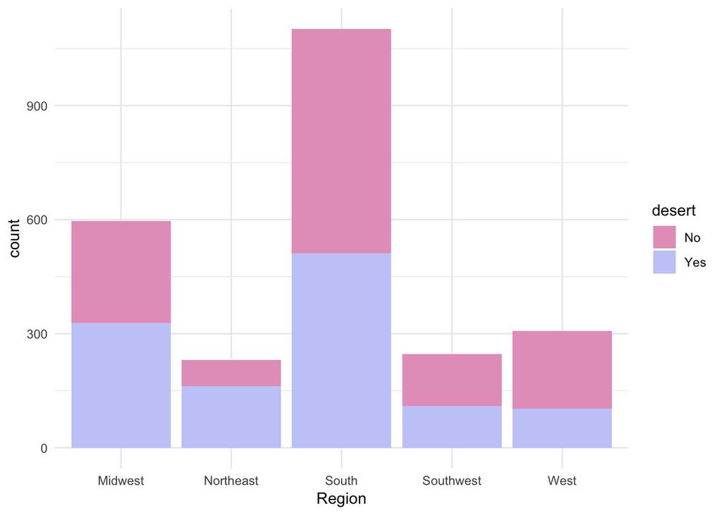

```r
bc_na <- bc %>%
  filter(!is.na(desert))

ggplot(bc_na, aes(x=Region)) +
  geom_bar(aes(fill=desert)) +
  scale_fill_manual(values=wes_palette(n=3, name="GrandBudapest2")) +
  theme_minimal()
```

One major limitation of this study is that any county with fewer than 1000 women in need cannot be defined as a desert, even if there are 0 clinics reported!

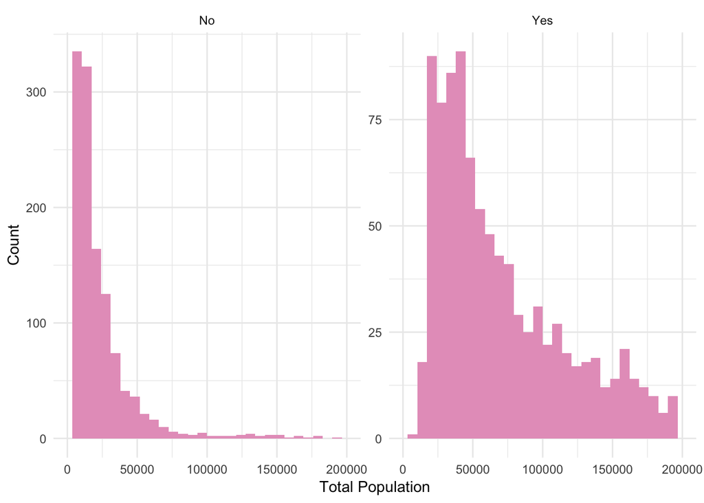

```r
ggplot(bc_na, aes(x=as.numeric(TotalPop))) +
  geom_histogram(fill="#E6A0C4") +
  facet_wrap(~desert, scales="free") +
  lims(x= c(0, 200000)) +
  labs(x="Total Population", y="Count") +
  theme_minimal()
```

Before we build models, we can check how our outcome (desert or women per clinic) compares to our key predictors. For the sake of visualization, I’ll plot women per clinic here.

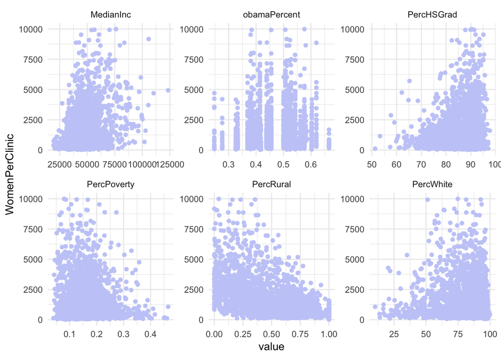

```r
predictors %>%
  gather(-WomenPerClinic, -TotalWomen, -TotalPop, -TotalWomenUnder20, key = "var", value = "value") %>%
  ggplot(aes(x = value, y = WomenPerClinic)) +
    geom_point(color="#C6CDF7") +
    facet_wrap(~ var, scales = "free") +
    lims(y=c(0, 10000)) +   # cutting off a fair amount of data for clarity
    theme_minimal()
```

We can also start to understand the characteristics of deserts with some numerical summaries:

```r
deserts <- bc %>%
  filter(desert=="Yes") %>%
  select(TotalWomen, TotalWomenUnder20, TotalPop, MedianInc, PercHSGrad, PercRural, PercPoverty, PercWhite, obamaPercent)  # selection for summary purposes

sapply(deserts, mean, na.rm=TRUE)
```

```
##        TotalWomen TotalWomenUnder20          TotalPop         MedianInc
##          13902.73           3194.34         210324.53          50298.08
##        PercHSGrad         PercRural       PercPoverty         PercWhite
##             86.35              0.38              0.16             81.68
##      obamaPercent
##              0.46
```

```r
not_deserts <- bc %>%
  filter(desert == "No") %>%
  select(TotalWomen, TotalWomenUnder20, TotalPop, MedianInc, PercHSGrad, PercRural, PercPoverty, PercWhite, obamaPercent)  # selection for summary purposes

sapply(not_deserts, mean, na.rm=TRUE)
```

```
##        TotalWomen TotalWomenUnder20          TotalPop         MedianInc
##           1648.53            405.72          26350.59          41948.65
##        PercHSGrad         PercRural       PercPoverty         PercWhite
##             83.50              0.73              0.18             82.32
##      obamaPercent
##              0.45
```

### Initial Model

We’ll start by implementing simple, non-spatial models. I think the most intuitive predictor is region, so we’ll start my modeling `WomenPerClinic` by `Region`. We can also checkout the plot below to confirm that the distributions are different in each region.

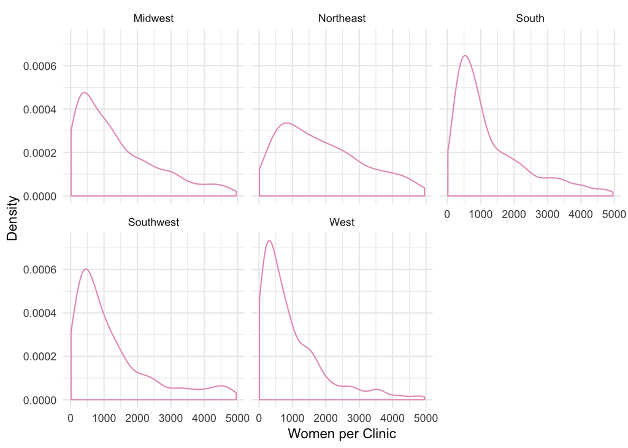

```r
ggplot(bc_na %>% filter(WomenPerClinic < 5000), aes(x=WomenPerClinic)) +
  geom_density(color="#E6A0C4") +
  facet_wrap(~Region) +
  labs(x="Women per Clinic", y="Density") +
  theme_minimal()
```

Based on previous data exploration, I expect `WomenPerClinic` to be approximately normally distributed around a different mean for each region. There are five regions in our data set: West, Midwest, Northeast, South, and Southwest, so I’ll create a beta prior for each of those.

```r
bc_na <- bc_na %>%
  mutate(regionPred = as.numeric(as.factor(Region)))

cap_mod_2 <- "model{
  # Model for Y
  for(i in 1:length(y)){
    y[i] ~ dnorm(beta0 + beta1[x[i]], tau)
  }

  beta0 ~ dnorm(0, 1/1000)
  beta1[1] <- 0
  beta1[2] ~ dnorm(0, taub)
  beta1[3] ~ dnorm(0, taub)
  beta1[4] ~ dnorm(0, taub)
  beta1[5] ~ dnorm(0, taub)
  tau   ~ dgamma(7, 10000)
  taub   ~ dgamma(7, 10000)

}"

cap_jags_2 <- jags.model(textConnection(cap_mod_2),
                         data=list(y=bc_na$WomenPerClinic, x=bc_na$regionPred),
                         inits = list(.RNG.name ="base::Wichmann-Hill", .RNG.seed = 454))
cap_sim_2 <- coda.samples(cap_jags_2,
                          variable.names=c("beta0", "beta1[2]", "beta1[3]", "beta1[3]", "beta1[4]", "beta1[5]", "tau", "taub"),
                          n.iter=10000)

cap_chains_2 <- data.frame(iteration = 1:10000, cap_sim_2[[1]])
```

Let’s check out our simulation:

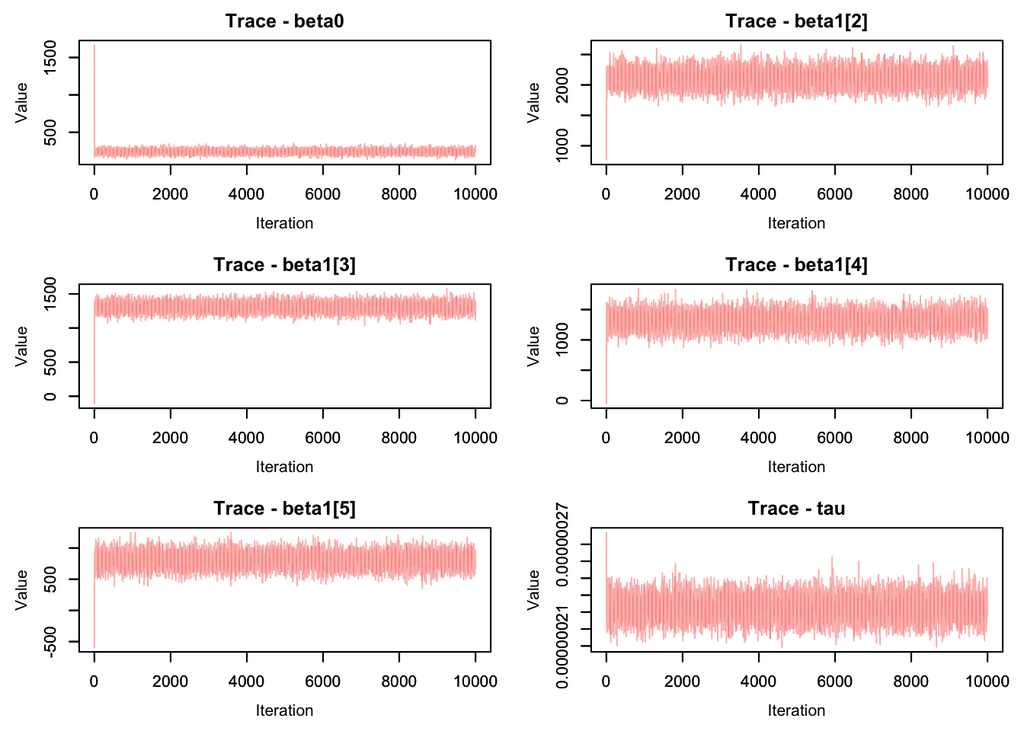

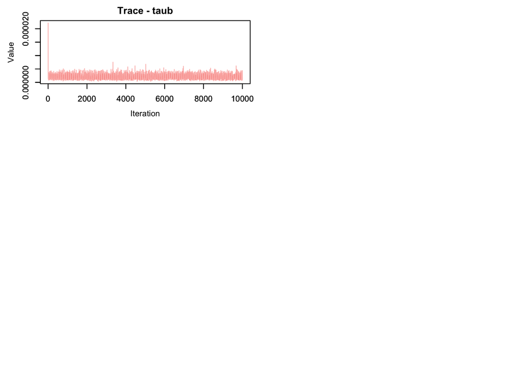

```r
MCMCtrace(object = cap_sim_2, pdf = FALSE, type = "trace", ISB = FALSE, iter=10000)
```

As we can see from the trace plots, my priors were way off to start. Luckily, I provided vague enough priors that the trace plots stabilize very quickly! We can also check out the coefficient estimates below.

```r
summary(cap_sim_2)
```

[output not shown]

This model starts to describe our data. However, we can do better! Moving forward, we will implement spatial conditional autogregressive models to better understand the spatial and hierarchical aspects of the data.